# Part II - An alarming Indonesian situation

## by Praprara Owodeha-Ashaka

## Investigation Overview

> The overall goal of this presentation is to show how calculators impact the performances of students in indonesia

## Dataset Overview

> PISA is a survey of students' skills and knowledge as they approach the end of compulsory education. This survey examines how well students have learned the school curriculum, how well prepared they are for life beyond school.

# 1. Are Graphing Calculators the way?

> Students who use graphing calculators have the highest math scores

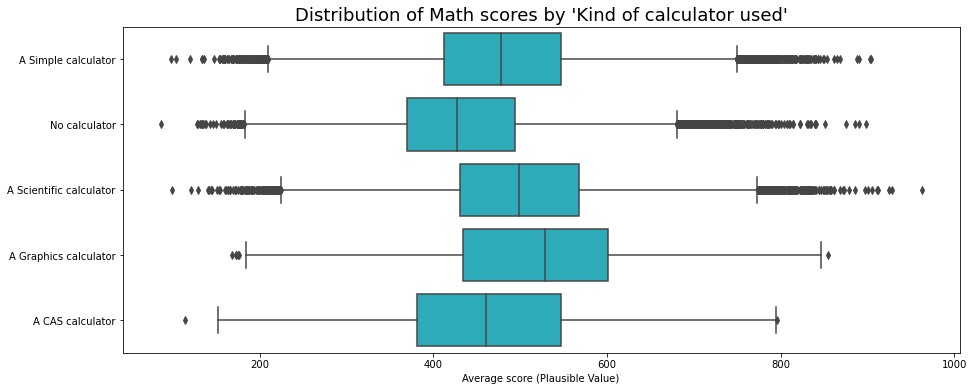

But Graphing calculators are used by a remarkably low amount of students.

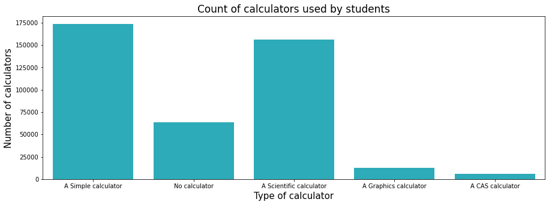

You may think that the price of the graphing calculator is the reason why it's so less popular than a simple calculator but this does not seem to be the case

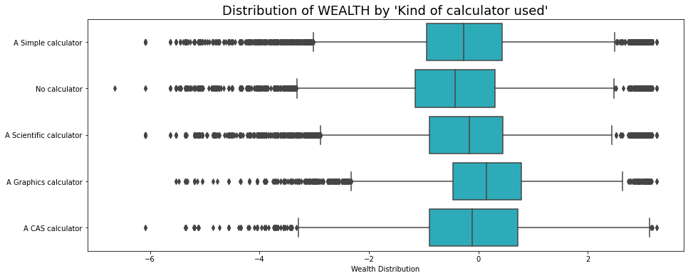

People who use graphing calculators are not miles richer then people who don't. Perhaps some more research should be done to find out why many students do not use graphing calculators

# 2. No calculators in Indonesia?

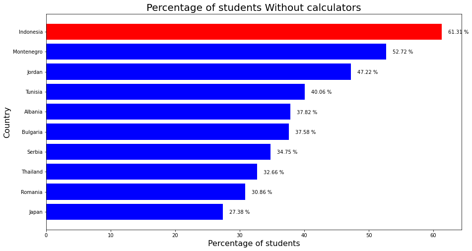

While this may be good for their mental work, the effect overall, does not look good. This is properly represented in the country having the 2nd lowest math and science scores

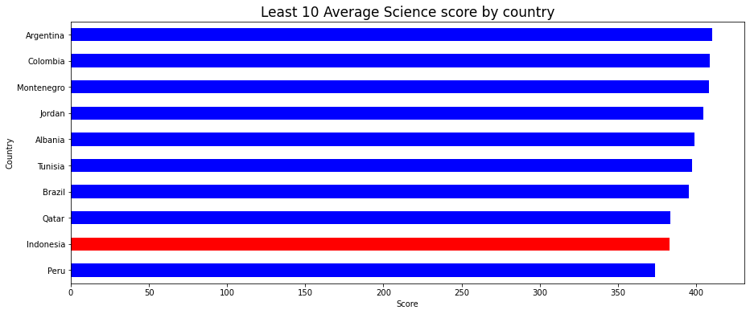

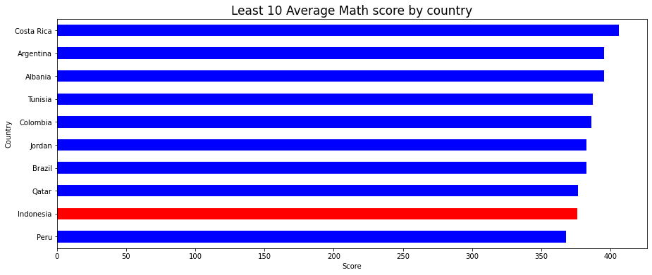

The fact that are higher in the rankings of average reading scores suggests strongly that the calculator is a big factor affceting their computational performace

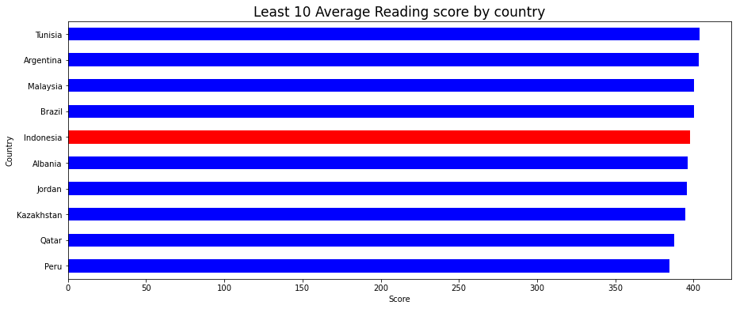

Something should be done to calculators (preferably Graphing😁) to Indonesian students

# 3. Money cannot buy it all

> Qatar is the richest country. But as we see from the previous plot, They rank 3rd lowest on both math and science scores and 2nd lowest on reading scores.

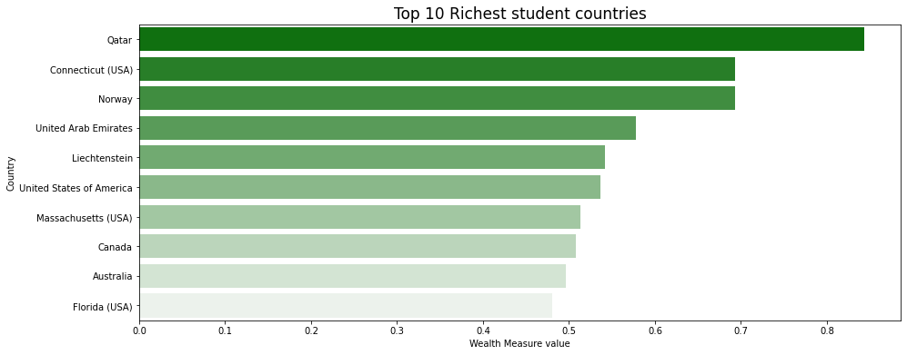

On the other hand, Indonesia is the poorest country ☹

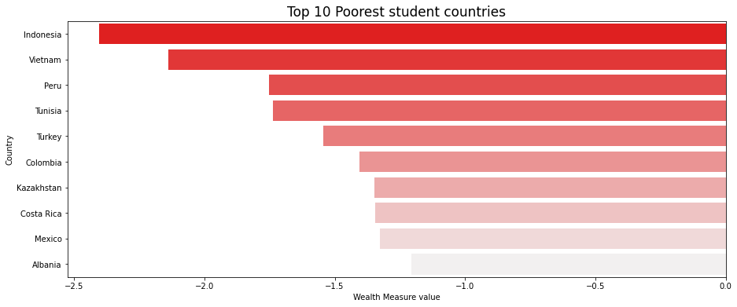

We must do what we can to change the situation of learners in Indonesia